# Statistical Data Analysis - Homework 1.1

Group 5

11/10/2019

> We load the libraries

```r
library(ggplot2)
library(lubridate)
library(scales)
library(ggpubr)
```

> We load the data and give a quick look at the header

```r
movies <- get(load("movies.RData"))
data <- head(movies)
```

From column 1 to column 8

| title | title_type | genre | runtime | mpaa_rating | studio | thtr_rel_year | thtr_rel_month |
| --- | --- | --- | --- | --- | --- | --- | --- |
| Filly Brown | Feature Film | Drama | 80 | R | Indomina Media Inc. | 2013 | 4 |
| The Dish | Feature Film | Drama | 101 | PG-13 | Warner Bros. Pictures | 2001 | 3 |
| Waiting for Guffman | Feature Film | Comedy | 84 | R | Sony Pictures Classics | 1996 | 8 |
| The Age of Innocence | Feature Film | Drama | 139 | PG | Columbia Pictures | 1993 | 10 |
| Malevolence | Feature Film | Horror | 90 | R | Anchor Bay Entertainment | 2004 | 9 |
| Old Partner | Documentary | Documentary | 78 | Unrated | Shcalo Media Group | 2009 | 1 |

From column 9 to column 16

| thtr_rel_day | dvd_rel_year | dvd_rel_month | dvd_rel_day | imdb_rating | imdb_num_votes | critics_rating | critics_score |
| --- | --- | --- | --- | --- | --- | --- | --- |
| 19 | 2013 | 7 | 30 | 5.5 | 899 | Rotten | 45 |
| 14 | 2001 | 8 | 28 | 7.3 | 12285 | Certified Fresh | 96 |
| 21 | 2001 | 8 | 21 | 7.6 | 22381 | Certified Fresh | 91 |
| 1 | 2001 | 11 | 6 | 7.2 | 35096 | Certified Fresh | 80 |
| 10 | 2005 | 4 | 19 | 5.1 | 2386 | Rotten | 33 |
| 15 | 2010 | 4 | 20 | 7.8 | 333 | Fresh | 91 |

From column 17 to column 24

| audience_rating | audience_score | best_pic_nom | best_pic_win | best_actor_win | best_actress_win | best_dir_win | top200_box |
| --- | --- | --- | --- | --- | --- | --- | --- |
| Upright | 73 | no | no | no | no | no | no |
| Upright | 81 | no | no | no | no | no | no |
| Upright | 91 | no | no | no | no | no | no |
| Upright | 76 | no | no | yes | no | yes | no |
| Spilled | 27 | no | no | no | no | no | no |
| Upright | 86 | no | no | no | no | no | no |

From column 25 to column 32

| director | actor1 | actor2 | actor3 | actor4 | actor5 | imdb_url | rt_url |
| --- | --- | --- | --- | --- | --- | --- | --- |
| Michael D. Olmos | Gina Rodriguez | Jenni Rivera | Lou Diamond Phillips | Emilio Rivera | Joseph Julian Soria | http://www.imdb.com/title/tt1869425/ | //www.rottentomatoes.com/m/filly_brown_2012/ |
| Rob Sitch | Sam Neill | Kevin Harrington | Patrick Warburton | Tom Long | Genevieve Mooy | http://www.imdb.com/title/tt0205873/ | //www.rottentomatoes.com/m/dish/ |
| Christopher Guest | Christopher Guest | Catherine O’Hara | Parker Posey | Eugene Levy | Bob Balaban | http://www.imdb.com/title/tt0118111/ | //www.rottentomatoes.com/m/waiting_for_guffman/ |
| Martin Scorsese | Daniel Day-Lewis | Michelle Pfeiffer | Winona Ryder | Richard E. Grant | Alec McCowen | http://www.imdb.com/title/tt0106226/ | //www.rottentomatoes.com/m/age_of_innocence/ |
| Stevan Mena | Samantha Dark | R. Brandon Johnson | Brandon Johnson | Heather Magee | Richard Glover | http://www.imdb.com/title/tt0388230/ | //www.rottentomatoes.com/m/10004684-malevolence/ |
| Chung-ryoul Lee | Choi Won-kyun | Lee Sam-soon | Moo | NA | NA | http://www.imdb.com/title/tt1334549/ | //www.rottentomatoes.com/m/old-partner/ |

> We create two new variables to study the data.

```r
movies$thtr_rel_date <- as.Date(paste0(movies$thtr_rel_year, "-", movies$thtr_rel_month, "-", movies$thtr_rel_day))
movies$thtr_rel_decade <- as.numeric(format(movies$thtr_rel_date,"%Y")) - (as.numeric(format(movies$thtr_rel_date,"%Y")) %% 10)
movies$thtr_rel_decade <- as.factor(movies$thtr_rel_decade)
```

[output not shown]

# SDA Homework 1.1

We chose the “Films” dataset and we are going to answer the following questions that we thought were interesting.

### 1. Is there a relationship between the type/genre and score?

### 2. Comparing different scores (critics/audience/imdb)

```
* is there any difference on the audience/critics score by genre?
```

### 3. Comparison best picture/oscar wins and score/oscar wins

```
* are oscar-awarded films more liked?
```

### 4. What are the trends over the years?

```
* Preferred month for releases? number of films by month (over the years? does it affect the score?)
* Does the genre change over the years?
* Do older films tend to have higher score/number of votes? if this is true, it could be because only good old films get remembered
```

### 5. Do actors and directors have a higher score once they won? (find the first film and see the tendency, look for sudden change)

> Let’s answer some questions then

## 4. What are the trends over the years?

### - Preferred month for releases? number of films by month (over the years? does it affect the score?)

> We start to count the movies per months to see if there is a pattern in all this time in the release months.

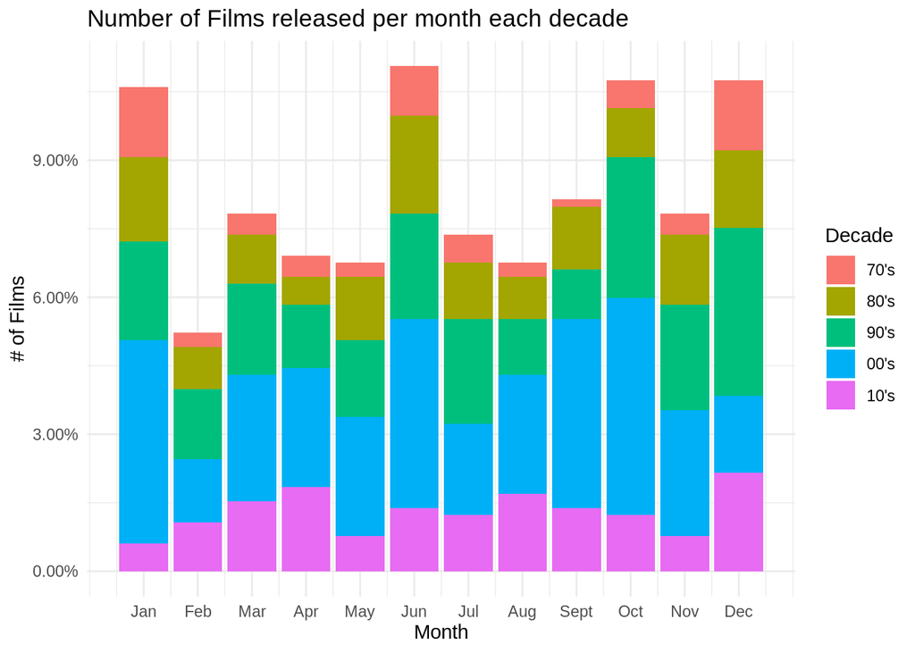

```r
ggplot(movies, aes(fill = thtr_rel_decade)) +
  geom_bar(aes(x = thtr_rel_month, (..count..)/sum(..count..))) +
  theme_minimal() +
  xlab("Month") +
  ylab("# of Films") +
  ggtitle("Number of Films released per month each decade ") +
  scale_fill_discrete(name = "Decade", labels=c("70's","80's","90's","00's","10's")) +
  scale_x_continuous(breaks=1:12,labels=c("Jan", "Feb", "Mar", "Apr","May", "Jun", "Jul", "Aug", "Sept", "Oct", "Nov", "Dec")) +
  scale_y_continuous(labels=scales::percent)
```

> We can see that overall there is a “pattern” of releases in the months of January, June, October and December, so let’s take a better look at this data by decade. We breakdown the previous graphs grouping the data by decade.

> We show the data by overall amount of movies and proportionally.

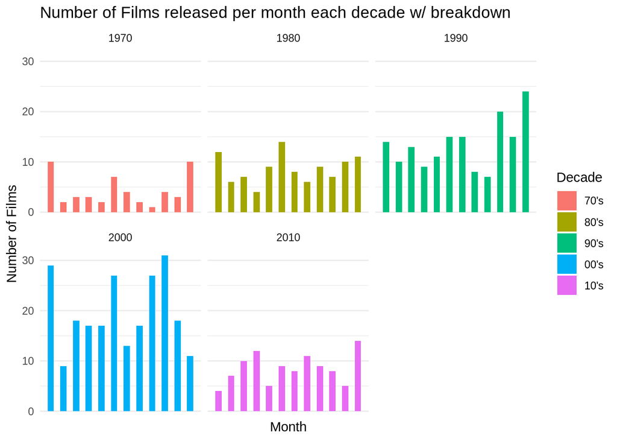

```r
ggplot(movies, aes(fill = thtr_rel_decade)) +
  geom_bar(aes(x = thtr_rel_month), width = 0.5) +
  facet_wrap(thtr_rel_decade ~ .) +
  #facet_wrap(facets = "thtr_rel_decade", ) +
  theme_minimal() +
  xlab("Month") +
  ylab("Number of Films") +
  ggtitle("Number of Films released per month each decade w/ breakdown") +
  scale_fill_discrete(name = "Decade", labels=c("70's","80's","90's","00's","10's")) +
  scale_x_discrete(breaks=1:12,labels=c("Jan", "Feb", "Mar", "Apr","May", "Jun", "Jul", "Aug", "Sept", "Oct", "Nov", "Dec"))
```

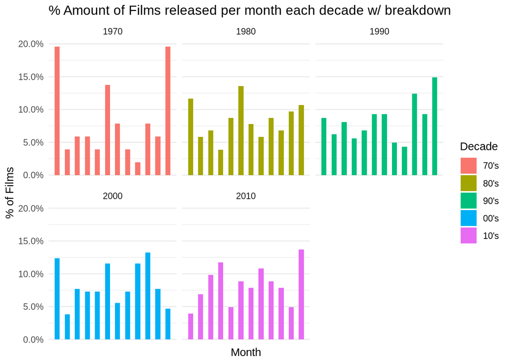

```r
ggplot(movies, aes(fill = thtr_rel_decade)) +
  geom_bar(aes(x = thtr_rel_month, y = (..prop..)), width = 0.5) +
  facet_wrap(thtr_rel_decade ~ .) +
  theme_minimal() +
  xlab("Month") +
  ylab("% of Films") +
  ggtitle("% Amount of Films released per month each decade w/ breakdown ") +
  scale_fill_discrete(name = "Decade", labels=c("70's","80's","90's","00's","10's")) +
  scale_x_discrete(breaks=1:12,labels=c("Jan", "Feb", "Mar", "Apr","May", "Jun", "Jul", "Aug", "Sept", "Oct", "Nov", "Dec"))  +
  scale_y_continuous(labels=scales::percent)
```

### - Does the genre change over the years (by decade)?

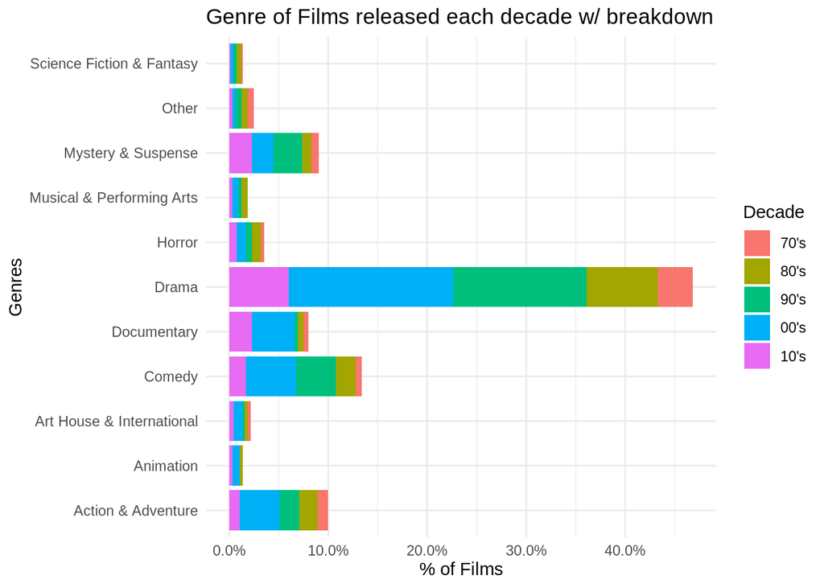

```r
ggplot(movies, aes(fill = thtr_rel_decade)) +
  geom_bar(aes(x = genre, y = (..count..)/sum(..count..))) +
  #facet_wrap(thtr_rel_decade ~ ., nrow = 1) +
  theme_minimal() +
  xlab("Genres") +
  ylab("% of Films") +
  ggtitle("Genre of Films released each decade w/ breakdown") +
  scale_fill_discrete(name = "Decade", labels=c("70's","80's","90's","00's","10's")) +
  scale_y_continuous(labels=scales::percent) +
  coord_flip()
```

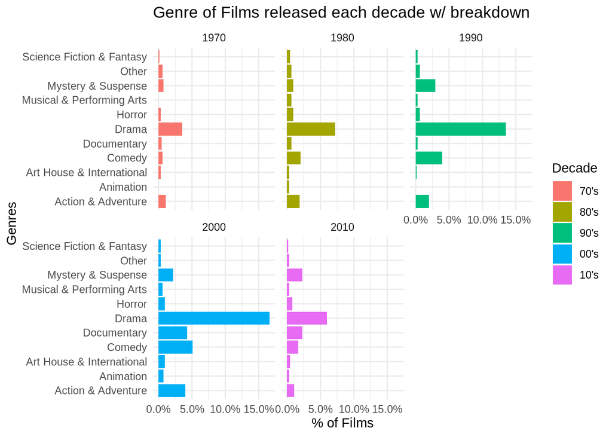

```r
# All the plots individually:
gen_1970 <- ggplot(movies[movies$thtr_rel_decade==1970,]) +
  geom_bar(aes(x = genre, y = (..count..)/sum(..count..)), fill = 'tomato') +
  facet_wrap(thtr_rel_decade ~ ., nrow = 2) +
  theme_minimal() +
  xlab("Genres") +
  ylab("% of Films") +
  ggtitle("Genre of Films released each decade w/ breakdown") +
  scale_y_continuous(labels=scales::percent) +
  coord_flip()

gen_1980 <- ggplot(movies[movies$thtr_rel_decade==1980,]) +
  geom_bar(aes(x = genre, y = (..count..)/sum(..count..)), fill = 'gold') +
  facet_wrap(thtr_rel_decade ~ ., nrow = 2) +
  theme_minimal() +
  xlab("Genres") +
  ylab("% of Films") +
  ggtitle("Genre of Films released each decade w/ breakdown") +
  scale_y_continuous(labels=scales::percent) +
  coord_flip()

gen_1990 <- ggplot(movies[movies$thtr_rel_decade==1990,]) +
  geom_bar(aes(x = genre, y = (..count..)/sum(..count..)), fill = 'limegreen') +
  facet_wrap(thtr_rel_decade ~ ., nrow = 2) +
  theme_minimal() +
  xlab("Genres") +
  ylab("% of Films") +
  ggtitle("Genre of Films released each decade w/ breakdown") +
  scale_y_continuous(labels=scales::percent) +
  coord_flip()

gen_2000 <- ggplot(movies[movies$thtr_rel_decade==2000,]) +
  geom_bar(aes(x = genre, y = (..count..)/sum(..count..)), fill = 'skyblue') +
  facet_wrap(thtr_rel_decade ~ ., nrow = 2) +
  theme_minimal() +
  xlab("Genres") +
  ylab("% of Films") +
  ggtitle("Genre of Films released each decade w/ breakdown") +
  scale_y_continuous(labels=scales::percent) +
  coord_flip()

gen_2010 <- ggplot(movies[movies$thtr_rel_decade==2010,]) +
  geom_bar(aes(x = genre, y = (..count..)/sum(..count..)), fill = 'orchid') +
  facet_wrap(thtr_rel_decade ~ ., nrow = 2) +
  theme_minimal() +
  xlab("Genres") +
  ylab("% of Films") +
  ggtitle("Genre of Films released each decade w/ breakdown") +
  scale_y_continuous(labels=scales::percent) +
  coord_flip()

# Facewrap of all the plots
ggplot(movies, aes(fill = thtr_rel_decade)) +
  geom_bar(aes(x = genre, y = (..count..)/sum(..count..))) +
  # all options & modifiers
  facet_wrap(thtr_rel_decade ~ ., nrow = 2) +
  theme_minimal() +
  xlab("Genres") +
  ylab("% of Films") +
  ggtitle("Genre of Films released each decade w/ breakdown") +
  scale_fill_discrete(name = "Decade", labels=c("70's","80's","90's","00's","10's")) +
  scale_y_continuous(labels=scales::percent) +
  coord_flip()
```

> We can see an increment over the years in the Documentary Genre, as well as in Mystery and Suspense.

### - Do older films tend to have higher score/number of votes? if this is true, it could be because only good old films get remembered

> Let’s see what is the amount of votes over the years that we have for all the films.

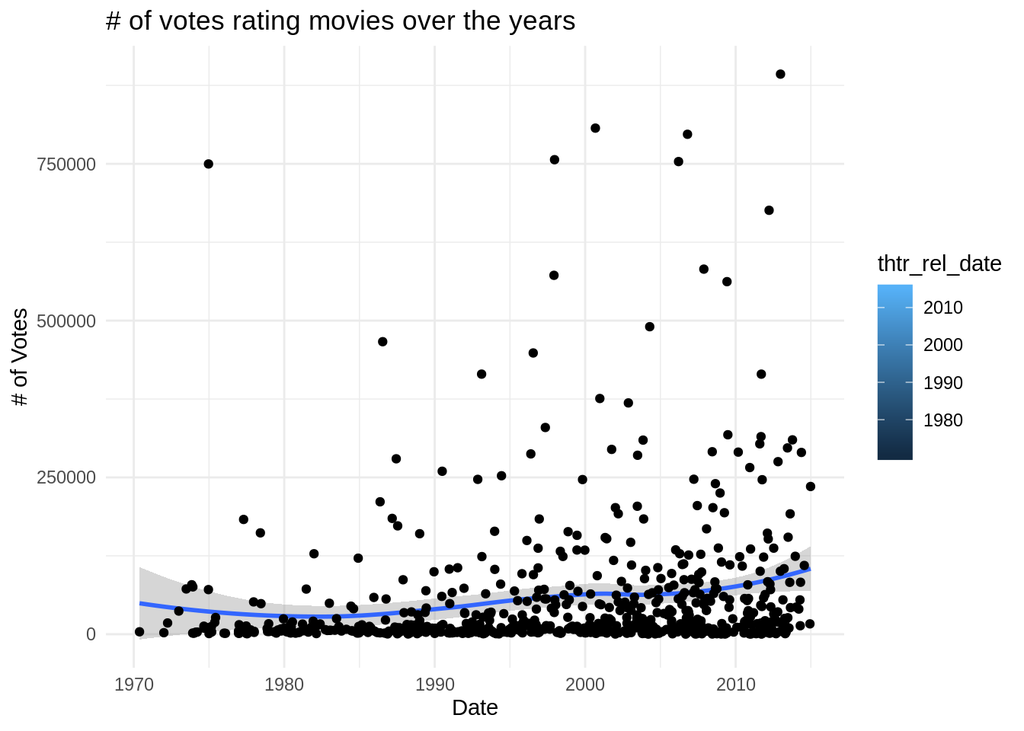

```r
ggplot(movies, aes(fill = thtr_rel_date)) + geom_smooth(aes(x = thtr_rel_date, y = imdb_num_votes)) + geom_point(aes(x = thtr_rel_date, y = imdb_num_votes)) + theme_minimal() + xlab("Date") + ylab("# of Votes") + ggtitle("# of votes rating movies over the years") # + scale_fill_discrete(name = "Decade", labels=c("70's","80's","90's","00's","10's"))
```

> Okay so it seems like the number of votes does increase over the years, but does it afect the overall score?

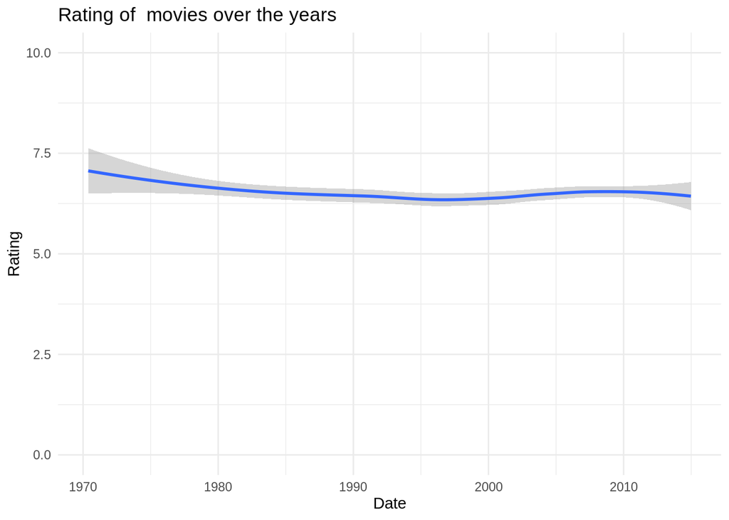

```r
ggplot(movies, aes(fill = thtr_rel_date)) +
  geom_smooth(aes(x = thtr_rel_date, y = imdb_rating)) +
  theme_minimal() +
  xlab("Date") +
  ylab("Rating") +
  ylim (0, 10) +
  ggtitle("Rating of  movies over the years")
```

> We can clearly see a decrease in overall score of this movies, but since it’s really minimal, it could also be because of random ratings variation.